# Data Analysis: Self-Paced Reading Task

## Research Questions and Predictions

**Research questions**:

1. Are object relative clauses (ORs) parsed slower than subject relative clauses (SRs) by adult Spanish-English bilinguals?
2. If so, does number mismatch between the two determiner phrases (DPs) facilitate their comprehension?

**Predictions**:

1. Adult Spanish-English bilinguals will show shorter reaction times (RTs) in SRs than in ORs.
2. Number mismatch between the two DPs will result in shorter RTs in ORs than number match.

## Data Analysis

This is a step by step guide on how the data collected by the self-paced reading task has been analyzed.

### 1. Library Loading

The following libraries are imported:

1. `tidyverse`, for cleaner data wrangling functions and access to other included packages, such as `ggplot2`.
2. `ggthemes`, to access the theme `theme_calc()`.
3. `lmerTest`, for more powerful mixed regression models.
4. `gt`, for table creation functions.

```r
library(tidyverse)
library(lmerTest)
library(ggthemes)
library(gt)
```

### 2. Importing and Processing Data

#### Importing

First, an example is imported to inspect the data set's variables and their data types.

```r
df_example <- read.csv("./data/32.csv")
summary(df_example)
```

```
       rt            response          trial_type         trial_index
 Min.   :    449   Length:309         Length:309         Min.   :  0.0
 1st Qu.:    777   Class :character   Class :character   1st Qu.: 87.0
 Median :   1006   Mode  :character   Mode  :character   Median :173.0
 Mean   :   8765                                         Mean   :172.9
 3rd Qu.:   1334                                         3rd Qu.:259.0
 Max.   :2322825                                         Max.   :344.0

 plugin_version      time_elapsed        part_id       task
 Length:309         Min.   :2325458   Min.   :32   Length:309
 Class :character   1st Qu.:2489442   1st Qu.:32   Class :character
 Mode  :character   Median :2578801   Median :32   Mode  :character
                    Mean   :2581325   Mean   :32
                    3rd Qu.:2675051   3rd Qu.:32
                    Max.   :2791465   Max.   :32

 item_number         item_type           segment          clause_type
 Length:309         Length:309         Length:309         Length:309
 Class :character   Class :character   Class :character   Class :character
 Mode  :character   Mode  :character   Mode  :character   Mode  :character




    number            stimulus           question         correct_answer
 Length:309         Length:309         Length:309         Length:309
 Class :character   Class :character   Class :character   Class :character
 Mode  :character   Mode  :character   Mode  :character   Mode  :character




 part_answer           correct
 Length:309         Min.   :0.0000
 Class :character   1st Qu.:1.0000
 Mode  :character   Median :1.0000
                    Mean   :0.8571
                    3rd Qu.:1.0000
                    Max.   :1.0000
                    NA's   :295
```

Having done this, now we know which are the specific names of each variable, which ones are of interest and the data type of their values.

We can now proceed to creating the full data set will all our participants' data. This is done by importing them and passing them through the `reduce()` function, which combines all the CSV files into a single data set. The keyword `rbind` makes sure that the individual data sets are merged as additional rows.

Note that only the following columns are selected:

- `part_id`, for the participants' ID number.
- `task`, for the kind of trial, item or question.
- `item_number`, for the items' ID number.
- `item_type`, for the type of item, experimental, practice or filler.
- `clause_type`, for the type fo clause, OR or SR.
- `number`, for the number condition, singular-singular (SS), plural-plural (PP), singular-plural (SP) or plural-singular (PS).
- `segment`, for the segment ID.
- `rt`, for the RTs.
- `correct`, for the accuracy of their responses to question tasks.

```r
df_raw <- reduce(
    list(
        select(read.csv("./data/32.csv"), part_id, task, item_number, item_type, clause_type, number, segment, rt, correct)
    ),
    rbind
)
summary(df_raw)
```

```
    part_id       task           item_number         item_type
 Min.   :32   Length:309         Length:309         Length:309
 1st Qu.:32   Class :character   Class :character   Class :character
 Median :32   Mode  :character   Mode  :character   Mode  :character
 Mean   :32
 3rd Qu.:32
 Max.   :32

 clause_type           number            segment                rt
 Length:309         Length:309         Length:309         Min.   :    449
 Class :character   Class :character   Class :character   1st Qu.:    777
 Mode  :character   Mode  :character   Mode  :character   Median :   1006
                                                          Mean   :   8765
                                                          3rd Qu.:   1334
                                                          Max.   :2322825

    correct
 Min.   :0.0000
 1st Qu.:1.0000
 Median :1.0000
 Mean   :0.8571
 3rd Qu.:1.0000
 Max.   :1.0000
 NA's   :295
```

#### Cleaning

After that, the data is cleaned.

Firstly, the rows are ordered by the participants' ID number with the `order()` function.

Secondly, the observations are filtered using the `filter()` function, keeping only those that involve experimental items and excluding question tasks.

Then, the function `mutate()` is used to transform the data types. `item_number` is transformed to numeric. The rest are transformed to factors.

Additionally, a new column `matching` is created which groups match and mismatch conditions.

Lastly, the `relocate()` function is used to make the `matching` column follow the `number` one.

```r
df_clean <- df_raw %>%
    .[order(.$part_id), ] %>%
    filter(.$item_type == "exp_item" & .$task == "item") %>%
    mutate(
        item_number = as.numeric(item_number),
        task = as.factor(task),
        item_type = as.factor(item_type),
        clause_type = as.factor(clause_type),
        number = as.factor(number),
        matching = as.factor(ifelse(number == "ss" | number == "pp", "match", "mismatch")),
        segment = as.factor(segment)
    ) %>%
    relocate(matching, .after = number)
summary(df_clean)
```

```
    part_id     task      item_number      item_type   clause_type number
 Min.   :32   item:192   Min.   :1.00   exp_item:192   or:96       pp:48
 1st Qu.:32              1st Qu.:3.25                  sr:96       ps:48
 Median :32              Median :5.50                              sp:48
 Mean   :32              Mean   :5.00                              ss:48
 3rd Qu.:32              3rd Qu.:7.25
 Max.   :32              Max.   :8.00

     matching  segment       rt            correct
 match   :96   s0:32   Min.   : 449.0   Min.   : NA
 mismatch:96   s1:32   1st Qu.: 766.2   1st Qu.: NA
               s2:32   Median : 973.5   Median : NA
               s3:32   Mean   :1183.0   Mean   :NaN
               s4:32   3rd Qu.:1271.5   3rd Qu.: NA
               s5:32   Max.   :6609.0   Max.   : NA
                                        NA's   :192
```

#### Normalizing

With the data looking like it should, now it is time to check for normal distribution. A plot is created that holds the data as it is.

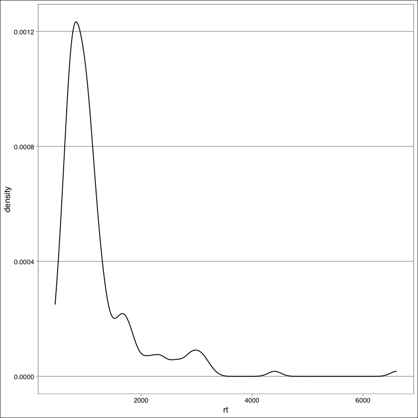

```r
skewed_plot <- df_clean %>%
    ggplot(aes(x = rt)) +
    geom_density() +
    theme_calc()
skewed_plot
```

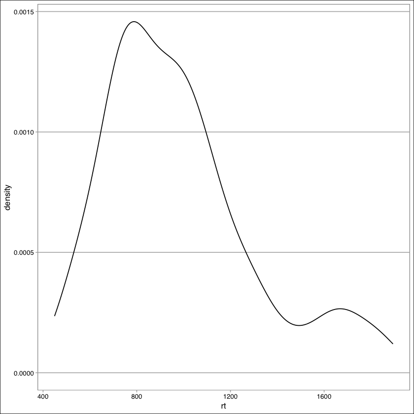

```r
q1 <- quantile(df_clean$rt, 0.25)
q3 <- quantile(df_clean$rt, 0.75)
iqr <- q3 - q1
lower_limit <- q1 - iqr * 1.5
upper_limit <- q3 + iqr * 1.5

df_clean <- df_clean %>%
    filter(.$rt > lower_limit & .$rt < upper_limit)

no_outlier_plot <- df_clean %>%
    ggplot(aes(x = rt)) +
    geom_density() +
    theme_calc()
no_outlier_plot
```

A second strategy that can be performed to further normalize the data is converting the continuos variable, RTs, into a logarithmic scale.

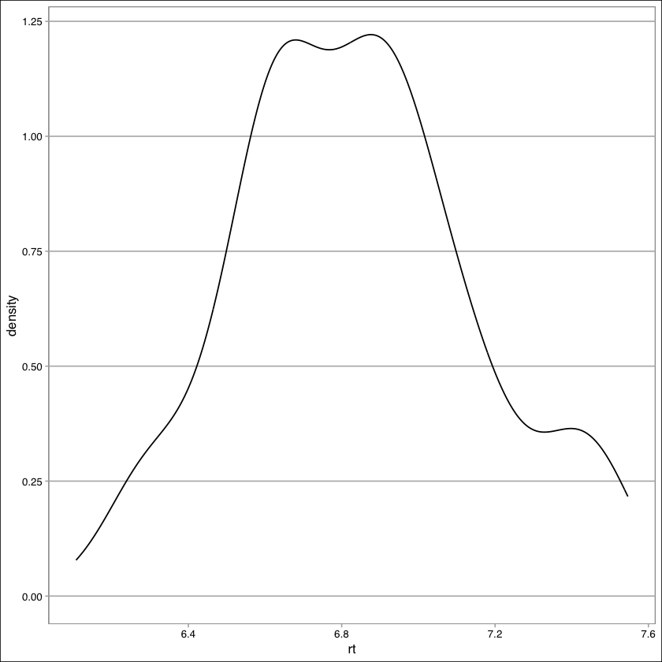

```r
df_clean <- df_clean %>%
    mutate(rt = log(rt))

normal_plot <- df_clean %>%
    ggplot(aes(x = rt)) +
    geom_density() +
    theme_calc()
normal_plot
```

### 3. Regression Models

Three regression models are created using the `lmer()` function.

- `lm_clause` checks for the correlation between RTs and clause type. Significantly higher RTs are expected for ORs.
- `lm_matching` checks for the interaction between clause type and matching on RTs. A significant effect of mismatch condition is expected in ORs but not in SRs.
- `lm_segment` checks for the interaction between clause type and segment on RTs. A significant effect of clause type is expected in segments 3, 4 and 5. The rest are filtered out.

#### RQ1: Clause Type

```r
lm_clause <- lmer(data = df_clean, rt ~ clause_type + (1 | item_number)) # ADD + (1 | part_id)
summary(lm_clause)

lm_segment <- lmer(data = df_clean, rt ~ clause_type * segment + (1 | item_number)) # ADD + (1 | part_id)
summary(lm_segment)
```

```
Linear mixed model fit by REML. t-tests use Satterthwaite's method [
lmerModLmerTest]
Formula: rt ~ clause_type + (1 | item_number)
   Data: df_clean

REML criterion at convergence: 88.7

Scaled residuals:
     Min       1Q   Median       3Q      Max
-2.39470 -0.70662 -0.09378  0.63033  2.41792

Random effects:
 Groups      Name        Variance Std.Dev.
 item_number (Intercept) 0.004186 0.0647
 Residual                0.091862 0.3031
Number of obs: 172, groups:  item_number, 4

Fixed effects:
               Estimate Std. Error        df t value Pr(>|t|)
(Intercept)     6.88224    0.04641   5.55817 148.279 3.26e-11 ***
clause_typesr  -0.08535    0.04628 167.20335  -1.844   0.0669 .
---
Signif. codes:  0 '***' 0.001 '**' 0.01 '*' 0.05 '.' 0.1 ' ' 1

Correlation of Fixed Effects:
            (Intr)
claus_typsr -0.516
```

```
Linear mixed model fit by REML. t-tests use Satterthwaite's method [
lmerModLmerTest]
Formula: rt ~ clause_type * segment + (1 | item_number)
   Data: df_clean

REML criterion at convergence: 65.1

Scaled residuals:
    Min      1Q  Median      3Q     Max
-2.3251 -0.6655 -0.0154  0.6016  3.2051

Random effects:
 Groups      Name        Variance Std.Dev.
 item_number (Intercept) 0.005717 0.07561
 Residual                0.070085 0.26474
Number of obs: 172, groups:  item_number, 4

Fixed effects:
                         Estimate Std. Error        df t value Pr(>|t|)
(Intercept)               6.67471    0.07814  29.97044  85.421  < 2e-16 ***
clause_typesr            -0.11375    0.09517 157.04426  -1.195 0.233800
segments1                 0.17897    0.09517 157.04426   1.881 0.061882 .
segments2                 0.04897    0.09517 157.04426   0.515 0.607612
segments3                 0.46780    0.09673 157.10779   4.836 3.13e-06 ***
segments4                 0.41123    0.11190 157.43795   3.675 0.000326 ***
segments5                 0.24022    0.10264 157.19113   2.340 0.020517 *
clause_typesr:segments1   0.17110    0.13348 157.02365   1.282 0.201805
clause_typesr:segments2   0.17672    0.13462 157.08593   1.313 0.191187
clause_typesr:segments3  -0.07495    0.13569 157.07613  -0.552 0.581495
clause_typesr:segments4  -0.05338    0.15081 157.24616  -0.354 0.723863
clause_typesr:segments5  -0.11992    0.14001 157.17496  -0.856 0.393040
---
Signif. codes:  0 '***' 0.001 '**' 0.01 '*' 0.05 '.' 0.1 ' ' 1

Correlation of Fixed Effects:
            (Intr) cls_ty sgmnt1 sgmnt2 sgmnt3 sgmnt4 sgmnt5 cls_:1 cls_:2
claus_typsr -0.629
segments1   -0.629  0.516
segments2   -0.629  0.516  0.516
segments3   -0.619  0.508  0.508  0.508
segments4   -0.536  0.440  0.440  0.440  0.432
segments5   -0.583  0.479  0.479  0.479  0.471  0.409
cls_typsr:1  0.448 -0.713 -0.713 -0.368 -0.362 -0.314 -0.341
cls_typsr:2  0.445 -0.707 -0.365 -0.707 -0.360 -0.312 -0.339  0.504
cls_typsr:3  0.441 -0.701 -0.362 -0.362 -0.713 -0.308 -0.336  0.500  0.496
cls_typsr:4  0.397 -0.632 -0.326 -0.326 -0.321 -0.742 -0.303  0.450  0.447
cls_typsr:5  0.427 -0.680 -0.351 -0.351 -0.345 -0.299 -0.733  0.485  0.481
            cls_:3 cls_:4
claus_typsr
segments1
segments2
segments3
segments4
segments5
cls_typsr:1
cls_typsr:2
cls_typsr:3
cls_typsr:4  0.442
cls_typsr:5  0.477  0.430
```

#### RQ2: Mismatch and ORs

```r
lm_matching <- lmer(data = df_clean, rt ~ clause_type * matching + (1 | item_number)) # ADD + (1 | part_id)
summary(lm_matching)
```

```
Linear mixed model fit by REML. t-tests use Satterthwaite's method [
lmerModLmerTest]
Formula: rt ~ clause_type * matching + (1 | item_number)
   Data: df_clean

REML criterion at convergence: 95.1

Scaled residuals:
     Min       1Q   Median       3Q      Max
-2.29422 -0.63598 -0.07451  0.63096  2.50248

Random effects:
 Groups      Name        Variance Std.Dev.
 item_number (Intercept) 0.004221 0.06497
 Residual                0.092485 0.30411
Number of obs: 172, groups:  item_number, 4

Fixed effects:
                                Estimate Std. Error        df t value Pr(>|t|)
(Intercept)                      6.88834    0.05804  13.11201 118.673   <2e-16
clause_typesr                   -0.06123    0.06684 165.15386  -0.916    0.361
matchingmismatch                -0.01176    0.06681 165.02918  -0.176    0.860
clause_typesr:matchingmismatch  -0.04671    0.09288 165.03531  -0.503    0.616

(Intercept)                    ***
clause_typesr
matchingmismatch
clause_typesr:matchingmismatch
---
Signif. codes:  0 '***' 0.001 '**' 0.01 '*' 0.05 '.' 0.1 ' ' 1

Correlation of Fixed Effects:
            (Intr) cls_ty mtchng
claus_typsr -0.597
mtchngmsmtc -0.596  0.518
cls_typsr:m  0.429 -0.719 -0.719
```

### 4. Visualizing Data

#### RQ1: Clause Type

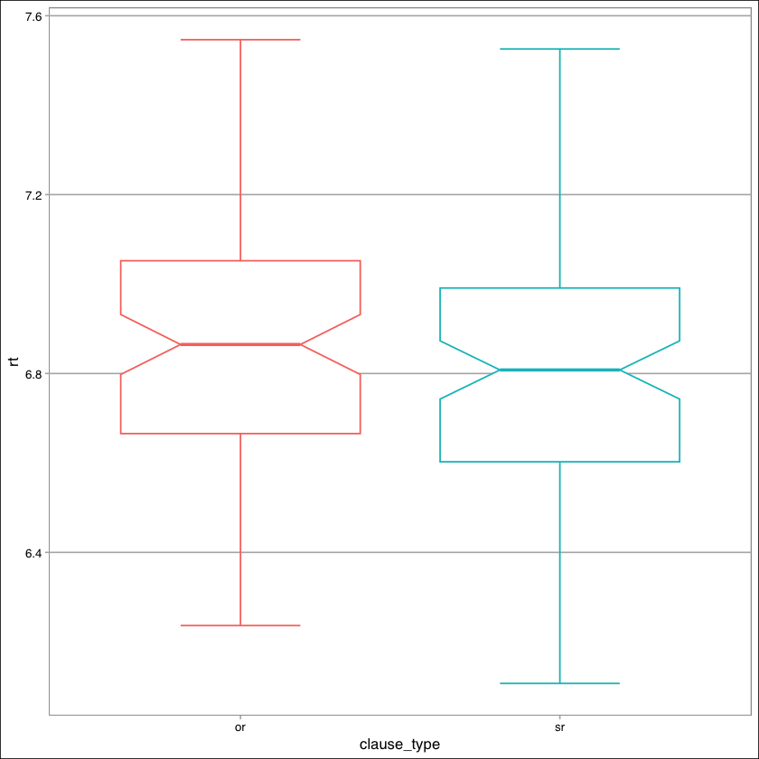

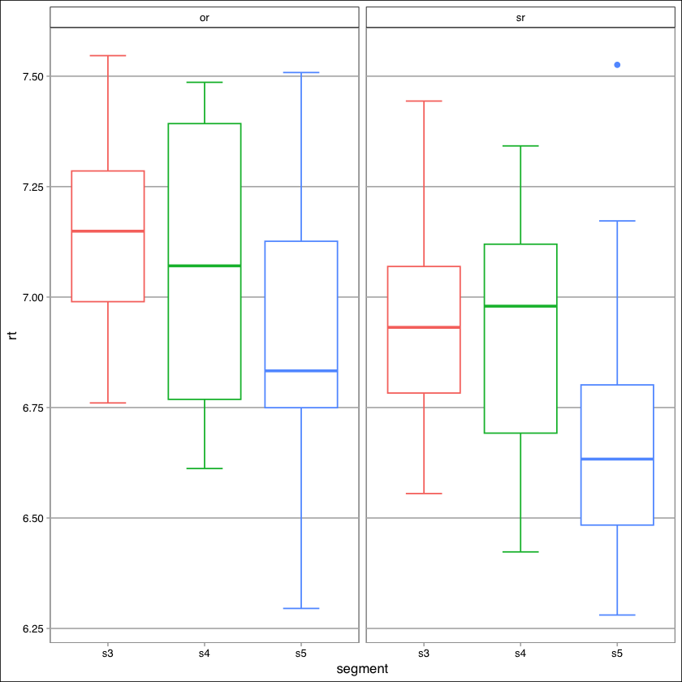

```r
lm_clause_plot <- df_clean %>%
    ggplot(aes(y = rt, x = clause_type, color = clause_type)) +
    geom_boxplot(show.legend = FALSE, staplewidth = 0.5, notch = TRUE) +
    theme_calc()
lm_clause_plot

lm_segment_plot <- df_clean %>%
    filter(segment == "s3" | segment == "s4" | segment == "s5") %>%
    ggplot(aes(y = rt, x = segment, color = segment)) +
    facet_wrap(~clause_type) +
    geom_boxplot(notch = FALSE, staplewidth = 0.5, show.legend = FALSE) + # Change notch to TRUE
    theme_calc()
lm_segment_plot
```

#### RQ2: Mismatch and ORs

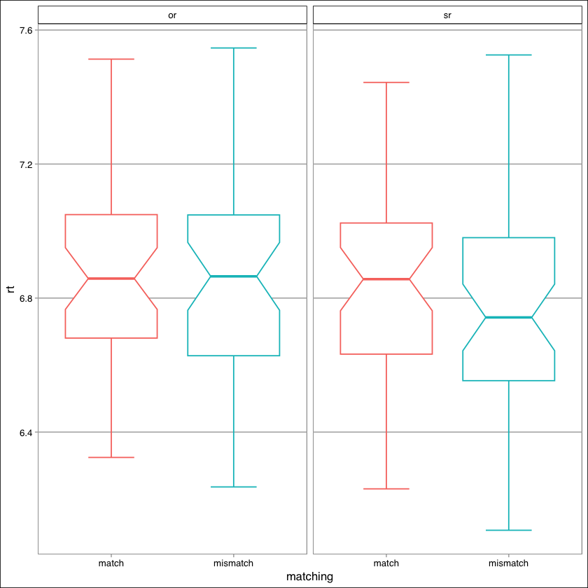

```r
lm_matching_plot <- df_clean %>%
    ggplot(aes(y = rt, x = matching, color = matching)) +
    geom_boxplot(notch = TRUE, staplewidth = 0.5, show.legend = FALSE) +
    facet_wrap(df_clean$clause_type) +
    theme_calc()
lm_matching_plot
```